# BSTA 504 Midterm

## Continent

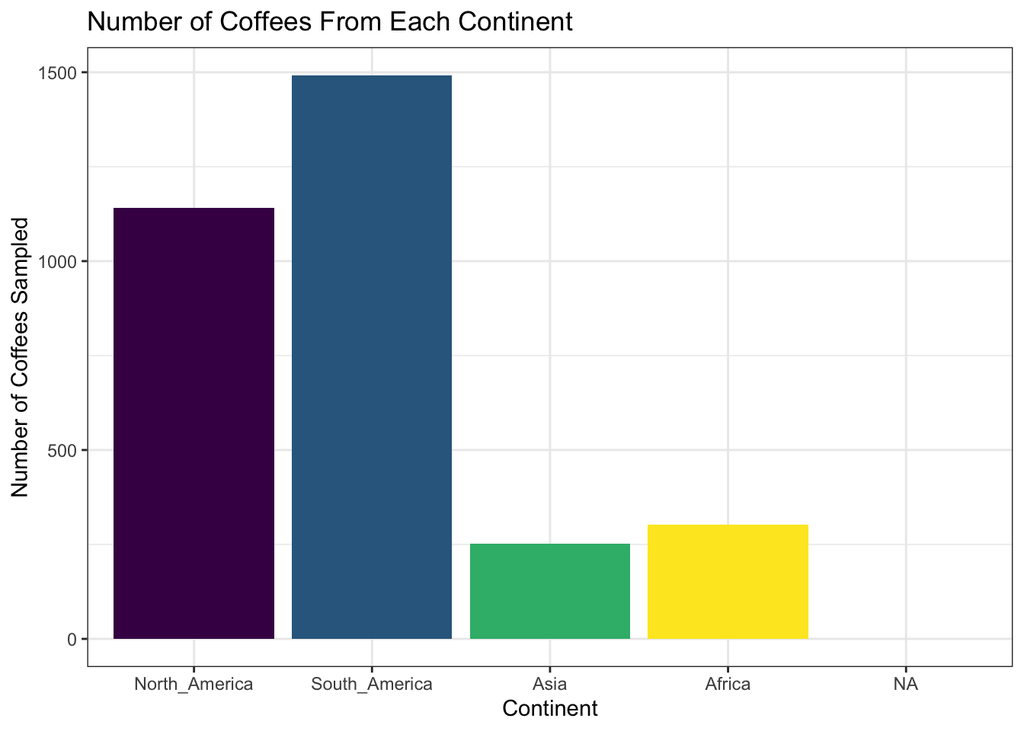

```r
ggplot(data = coffee_ratings,
       aes(x = continent,
           fill = continent)) +
  geom_bar() +
  scale_fill_viridis_d() +
  labs(
    title = "Number of Coffees From Each Continent",
    x = "Continent",
    y = "Number of Coffees Sampled"
  ) +
  theme_bw() +
  theme(legend.position = "none")
```

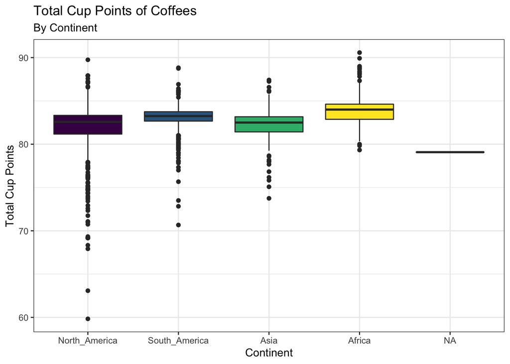

```r
ggplot(data = (coffee_ratings %>% filter(total_cup_points > 0)), # I removed an outlier
       aes(x = continent,
           y = total_cup_points,
           fill = continent)) +
  geom_boxplot() +
  scale_fill_viridis_d() +
  labs(
    title = "Total Cup Points of Coffees",
    subtitle = "By Continent",
    x = "Continent",
    y = "Total Cup Points"
  ) +
  theme_bw() +
  theme(legend.position = "none")
```

- South America produced the largest number of coffees, followed by North America, then Africa, and finally Asia. African countries appear to score the best, followed by South America, then Asia, and then North America. That being said, all continents appear to have a very broad range of total cup points.

## Species

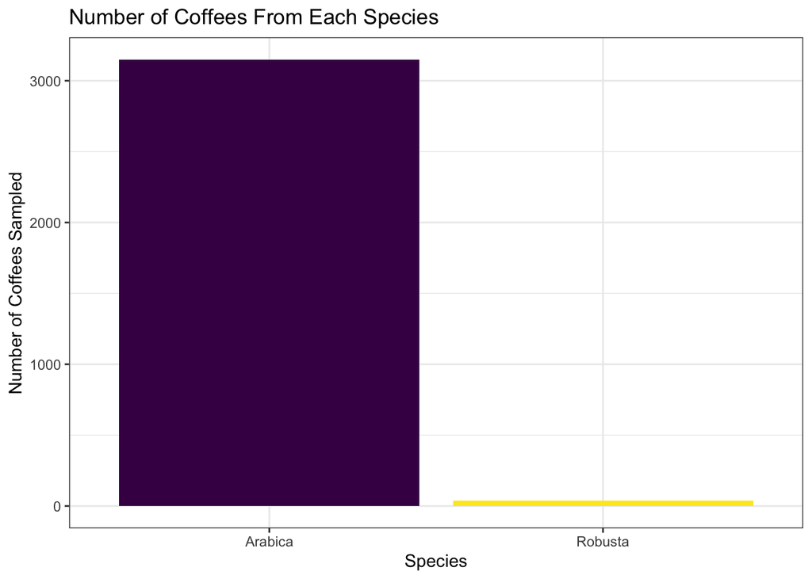

```r
ggplot(data = coffee_ratings,
       aes(x = species,
           fill = species)) +
  geom_bar() +
  scale_fill_viridis_d() +
  labs(
    title = "Number of Coffees From Each Species",
    x = "Species",
    y = "Number of Coffees Sampled"
  ) +
  theme_bw() +
  theme(legend.position = "none")
```

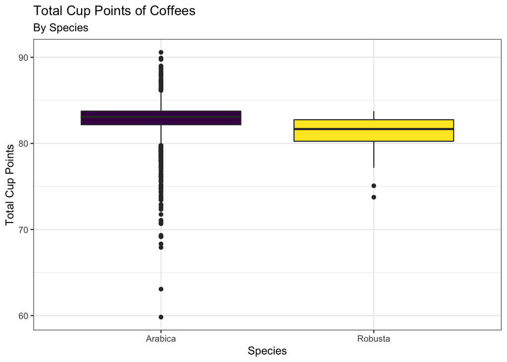

```r
ggplot(data = (coffee_ratings %>% filter(total_cup_points > 0)), # I removed an outlier
       aes(x = species,
           y = total_cup_points,
           fill = species)) +
  geom_boxplot() +
  scale_fill_viridis_d() +
  labs(
    title = "Total Cup Points of Coffees",
    subtitle = "By Species",
    x = "Species",
    y = "Total Cup Points"
  ) +
  theme_bw() +
  theme(legend.position = "none")
```

- The vast majority of coffees were Arabica. Arabica coffees appear to score more total cup points, on average, than Robusta coffees. That being said, the range of total cup points for Arabica coffees is much wider than that of Robusta coffees.

## Altitude

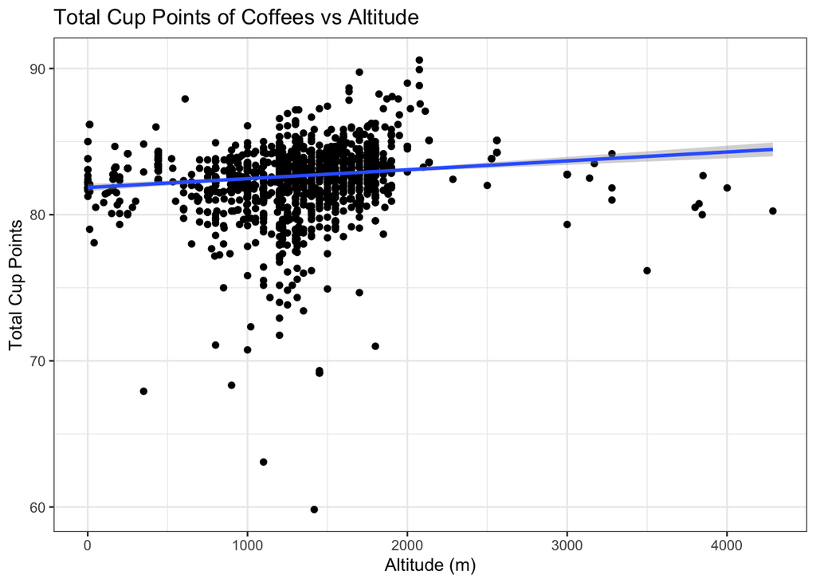

```r
ggplot(data = (coffee_ratings %>% filter(total_cup_points > 0)), # I removed an outlier
       aes(x = altitude_mean_meters,
           y = total_cup_points)) +
  geom_point() +
  geom_smooth(method = "lm") +
  labs(
    title = "Total Cup Points of Coffees vs Altitude",
    x = "Altitude (m)",
    y = "Total Cup Points"
  ) +
  theme_bw()
```

- From the scatterplot, it appears that average cup points increases as altitude increases. The correlation appears to be fairly weak, though.

## Number of Bags Tested

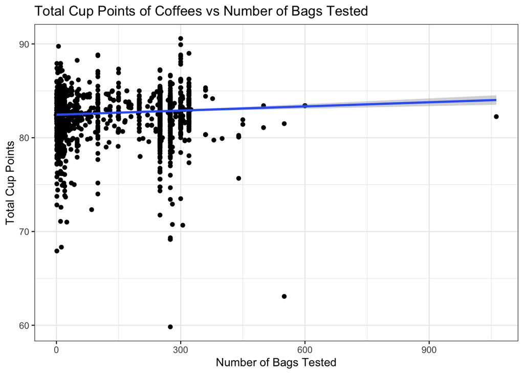

```r
ggplot(data = (coffee_ratings %>% filter(total_cup_points > 0)), # I removed an outlier
       aes(x = number_of_bags,
           y = total_cup_points)) +
  geom_point() +
  geom_smooth(method = "lm") +
  labs(
    title = "Total Cup Points of Coffees vs Number of Bags Tested",
    x = "Number of Bags Tested",
    y = "Total Cup Points"
  ) +
  theme_bw()
```

- As number of bags tested increases, so does the total cup points. That being said, the increase is very modest and likely not significant.